# Introduction

Today we'll dive deep into a dataset all about LEGO. From the dataset we can ask whole bunch of interesting questions about the history of the LEGO company, their product offering, and which LEGO set ultimately rules them all:

- What is the most enormous LEGO set ever created and how many parts did it have?
- How did the LEGO company start out? In which year were the first LEGO sets released and how many sets did the company sell when it first launched?
- Which LEGO theme has the most sets? Is it one of LEGO's own themes like Ninjago or a theme they licensed liked Harry Potter or Marvel Superheroes?
- When did the LEGO company really expand its product offering? Can we spot a change in the company strategy based on how many themes and sets did it released year-on-year?
- Did LEGO sets grow in size and complexity over time? Do older LEGO sets tend to have more or fewer parts than newer sets?

**Data Source**

[Rebrickable](https://rebrickable.com/downloads/) has compiled data on all the LEGO pieces in existence. I recommend you use download the .csv files provided in this lesson.

**Adding image:** `<img src=assets/bricks.jpg>`

[figure not shown]

# Import Statements

```python
import pandas as pd
import matplotlib.pyplot as plt
```

# Data Exploration

**Challenge**: How many different colours does the LEGO company produce? Read the colors.csv file in the data folder and find the total number of unique colours. Try using the [.nunique() method](https://pandas.pydata.org/pandas-docs/stable/reference/api/pandas.DataFrame.nunique.html?highlight=nunique#pandas.DataFrame.nunique) to accomplish this.

```python
colors_df = pd.read_csv('data/colors.csv')
colors_df.head()
```

|  | id | name | rgb | is_trans |
| --- | --- | --- | --- | --- |
| 0 | -1 | Unknown | 0033B2 | f |
| 1 | 0 | Black | 05131D | f |
| 2 | 1 | Blue | 0055BF | f |
| 3 | 2 | Green | 237841 | f |
| 4 | 3 | Dark Turquoise | 008F9B | f |

```python
colors_df.isna().values.any()
```

```
False
```

```python
colors_df.tail()
```

|  | id | name | rgb | is_trans |
| --- | --- | --- | --- | --- |
| 130 | 1004 | Trans Flame Yellowish Orange | FCB76D | t |
| 131 | 1005 | Trans Fire Yellow | FBE890 | t |
| 132 | 1006 | Trans Light Royal Blue | B4D4F7 | t |
| 133 | 1007 | Reddish Lilac | 8E5597 | f |
| 134 | 9999 | [No Color] | 05131D | f |

The first rown (Unknown) and the last row ([No Color]) should probably be deleted but let's leave as it is for now.

```python
colors_df.nunique()
# I can use nunique() on a column/series instead.
colors_df.name.nunique()
```

```
135
```

It seems we have 135 different color names and IDs, but 124 different rgb color codes (some are the same).

**Challenge**: Find the number of transparent colours where `is_trans == 't'` versus the number of opaque colours where `is_trans == 'f'`. See if you can accomplish this in two different ways.

```python
colors_df[colors_df.is_trans == 't'].count()
```

```
id          28
name        28
rgb         28
is_trans    28
dtype: int64
```

```python
colors_df[colors_df.is_trans == 'f'].count()
```

```
id          107
name        107
rgb         107
is_trans    107
dtype: int64
```

One way you can do this is through combining our old friend, the .groupby() method, with the .count() method.

```python
colors_df.groupby('is_trans').count()
```

| is_trans | id | name | rgb |
| --- | --- | --- | --- |
| f | 107 | 107 | 107 |
| t | 28 | 28 | 28 |

The .value_counts() method is also a very quick way of finding the number of members of each category.

```python
colors_df.is_trans.value_counts()
```

```
f    107
t     28
Name: is_trans, dtype: int64
```

**Challenge**: Change this into an h3 section heading: Understanding LEGO Themes vs. LEGO Sets

### Understanding LEGO Themes vs. LEGO Sets

Walk into a LEGO store and you will see their products organised by theme. Their themes include Star Wars, Batman, Harry Potter and many more.

**Challenge**: Display this image: https://i.imgur.com/aKcwkSx.png

[figure not shown]

A lego **set** is a particular box of LEGO or product. Therefore, a single theme typically has many different sets.

**Challenge**: Display this image https://i.imgur.com/whB1olq.png

[figure not shown]

The `sets.csv` data contains a list of sets over the years and the number of parts that each of these sets contained.

**Challenge**: Read the sets.csv data and take a look at the first and last couple of rows.

```python
sets = pd.read_csv('data/sets.csv')
sets.head()
```

|  | set_num | name | year | theme_id | num_parts |
| --- | --- | --- | --- | --- | --- |
| 0 | 001-1 | Gears | 1965 | 1 | 43 |
| 1 | 0011-2 | Town Mini-Figures | 1978 | 84 | 12 |
| 2 | 0011-3 | Castle 2 for 1 Bonus Offer | 1987 | 199 | 0 |
| 3 | 0012-1 | Space Mini-Figures | 1979 | 143 | 12 |
| 4 | 0013-1 | Space Mini-Figures | 1979 | 143 | 12 |

```python
sets.shape
```

```
(15710, 5)
```

```python
sets.isna().values.any()
```

```
False
```

**Challenge**: In which year were the first LEGO sets released and what were these sets called?

**Challenge**: How many different sets did LEGO sell in their first year? How many types of LEGO products were on offer in the year the company started?

```python
sets.year.min()
```

```
1949
```

```python
sets[sets.year==1949]
```

|  | set_num | name | year | theme_id | num_parts |
| --- | --- | --- | --- | --- | --- |
| 9521 | 700.1-1 | Extra-Large Gift Set (ABB) | 1949 | 365 | 142 |
| 9534 | 700.2-1 | Large Gift Set (ABB) | 1949 | 365 | 178 |
| 9539 | 700.3-1 | Medium Gift Set (ABB) | 1949 | 365 | 142 |
| 9544 | 700.A-1 | Small Brick Set (ABB) | 1949 | 371 | 24 |
| 9545 | 700.B-1 | Small Doors and Windows Set (ABB) | 1949 | 371 | 12 |

**Challenge**: Find the top 5 LEGO sets with the most number of parts.

```python
sets.sort_values('num_parts', ascending=False).head()
```

|  | set_num | name | year | theme_id | num_parts |
| --- | --- | --- | --- | --- | --- |
| 15004 | BIGBOX-1 | The Ultimate Battle for Chima | 2015 | 571 | 9987 |
| 11183 | 75192-1 | UCS Millennium Falcon | 2017 | 171 | 7541 |
| 10551 | 71043-1 | Hogwarts Castle | 2018 | 246 | 6020 |
| 295 | 10256-1 | Taj Mahal | 2017 | 673 | 5923 |
| 221 | 10189-1 | Taj Mahal | 2008 | 673 | 5922 |

**Challenge**: Use `.groupby()` and `.count()` to show the number of LEGO sets released year-on-year. How do the number of sets released in 1955 compare to the number of sets released in 2019?

```python
sets.groupby('year').count()
```

| year | set_num | name | theme_id | num_parts |
| --- | --- | --- | --- | --- |
| 1949 | 5 | 5 | 5 | 5 |
| 1950 | 6 | 6 | 6 | 6 |
| 1953 | 4 | 4 | 4 | 4 |
| 1954 | 14 | 14 | 14 | 14 |
| 1955 | 28 | 28 | 28 | 28 |
| ... | ... | ... | ... | ... |
| 2017 | 786 | 786 | 786 | 786 |
| 2018 | 816 | 816 | 816 | 816 |
| 2019 | 840 | 840 | 840 | 840 |
| 2020 | 674 | 674 | 674 | 674 |
| 2021 | 3 | 3 | 3 | 3 |

71 rows × 4 columns

**Challenge**: Show the number of LEGO releases on a line chart using Matplotlib.  
Now, let's create a new Series called sets_by_year which has the years as the index and the number of sets as the value.

```python
sets_by_year = sets.groupby('year').count().set_num
sets_by_year = sets_by_year.to_frame(name='nb_of_sets')
sets_by_year
```

| year | nb_of_sets |
| --- | --- |
| 1949 | 5 |
| 1950 | 6 |
| 1953 | 4 |
| 1954 | 14 |
| 1955 | 28 |
| ... | ... |
| 2017 | 786 |
| 2018 | 816 |
| 2019 | 840 |
| 2020 | 674 |
| 2021 | 3 |

71 rows × 1 columns

**Challenge**: Note that the .csv file is from late 2020, so to plot the full calendar years, you will have to exclude some data from your chart. Can you use the slicing techniques covered in Day 21 to avoid plotting the last two years? The same syntax will work on Pandas DataFrames.

Given the dataset does not include a full calendar year for 2020, it's best to exclude the last two rows to get a better picture.

```python
sets.groupby('year').count().set_num[:-2]
```

```
year
1949      5
1950      6
1953      4
1954     14
1955     28
       ...
2015    774
2016    757
2017    786
2018    816
2019    840
Name: set_num, Length: 69, dtype: int64
```

```python
sets_by_year = sets.groupby('year').count().set_num.iloc[:-2]
sets_by_year = sets_by_year.to_frame(name='nb_of_sets')
sets_by_year.tail(3)  # We can see 2021 was removed
```

| year | nb_of_sets |
| --- | --- |
| 2017 | 786 |
| 2018 | 816 |
| 2019 | 840 |

I could also use the slicing when doing the plot: `plt.plot(sets_by_year.index[:-2], sets_by_year.set_num[:-2])`

**Challenge**: Show the number of LEGO releases on a line chart using Matplotlib.

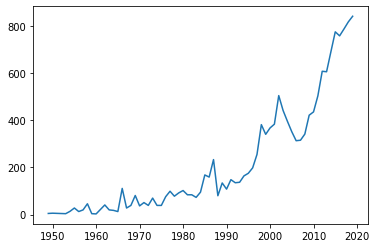

```python
plt.plot(sets_by_year.index, sets_by_year.nb_of_sets)
```

### Aggregate Data with the Python .agg() Function

Let's work out the number of different themes shipped by year. This means we have to count the number of unique theme_ids per calendar year.

```python
themes_by_year = sets.groupby('year').agg({'theme_id': 'nunique'})  # see notes p.160 to know how .agg() works
themes_by_year = themes_by_year[:-2].rename(columns={'theme_id': 'nb_of_themes'})  # removing last two rows and renaming column
themes_by_year
```

| year | nb_of_themes |
| --- | --- |
| 1949 | 2 |
| 1950 | 1 |
| 1953 | 2 |
| 1954 | 2 |
| 1955 | 4 |
| ... | ... |
| 2015 | 98 |
| 2016 | 92 |
| 2017 | 89 |
| 2018 | 93 |
| 2019 | 78 |

69 rows × 1 columns

Code used in the course: `themes_by_year = sets.groupby('year').agg({'theme_id': pd.Series.nunique})`

**Challenge**: Plot the number of themes released by year on a line chart. Only include the full calendar years (i.e., exclude 2020 and 2021).

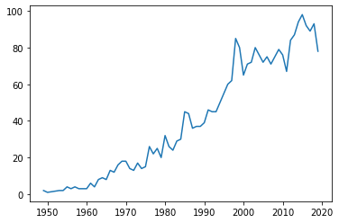

```python
plt.plot(themes_by_year)
```

Wouldn't it be nice to have the number of themes and the number sets on the same chart? But what do we get if we just plot both of them the way we have before?

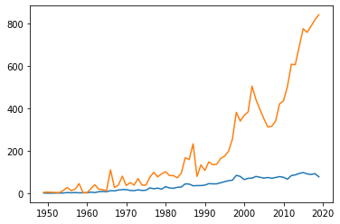

```python
plt.plot(themes_by_year)
plt.plot(sets_by_year)
```

Well, that's not very informative! The problem is that the "number of themes" and the "number of sets" have very different scales. The theme number ranges between 0 and 90, while the number of sets ranges between 0 and 900. So what can we do?

### Line Charts with Two Seperate Axes

We need to be able to configure and plot our data on two separate axes on the same chart. This involves getting hold of an axis object from Matplotlib.

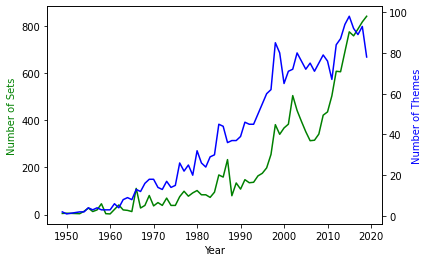

```python
ax1 = plt.gca() # Get Current Axes
ax2 = ax1.twinx() # The x axis in ax2 is the same as in ax1, making essentially the two y-axis different

# We must also add some styling, otherwise they're the same color
ax1.plot(sets_by_year, color='g')
ax2.plot(themes_by_year, color='b')

# Adding the labels
ax1.set_xlabel('Year')
ax1.set_ylabel('Number of Sets', color='green')
ax2.set_ylabel('Number of Themes', color='blue')
```

#### Complexity Over Time

Have LEGO sets become larger and more complex over time? Let's work out the average number of parts per LEGO set. This is the perfect time to revise how to use the .agg() function.

**Challenge**: Use the `.groupby()` and `.agg()` function together to figure out the average number of parts per set. How many parts did the average LEGO set released in 1954 compared to say, 2017?

```python
parts_per_set = sets.groupby('year').agg({'num_parts': 'mean'})[:-2]
parts_per_set.rename(columns={'num_parts': 'avg_num_parts'}, inplace=True)
parts_per_set
```

| year | avg_num_parts |
| --- | --- |
| 1949 | 99.600000 |
| 1950 | 1.000000 |
| 1953 | 13.500000 |
| 1954 | 12.357143 |
| 1955 | 36.607143 |
| ... | ... |
| 2015 | 191.379845 |
| 2016 | 209.920740 |
| 2017 | 221.840967 |
| 2018 | 213.618873 |
| 2019 | 207.510714 |

69 rows × 1 columns

### Scatter Plots in Matplotlib

**Challenge**: Has the size and complexity of LEGO sets increased over time based on the number of parts? Plot the average number of parts over time using a Matplotlib scatter plot. See if you can use the [scatter plot documentation](https://matplotlib.org/3.1.0/api/_as_gen/matplotlib.pyplot.scatter.html) before I show you the solution. Do you spot a trend in the chart?

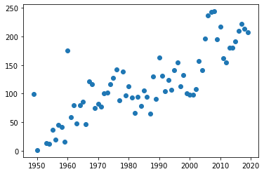

```python
plt.scatter(parts_per_set.index, parts_per_set.avg_num_parts)
```

### Number of Sets per LEGO Theme

LEGO has licensed many hit franchises from Harry Potter to Marvel Super Heros to many others. But which theme has the largest number of individual sets?

To count the number of sets per Theme we can use the .value_counts() method on our theme_id column.

```python
sets.theme_id.value_counts()
```

```
158    753
501    656
494    398
435    356
503    329
      ...
307      1
215      1
361      1
210      1
414      1
Name: theme_id, Length: 571, dtype: int64
```

But there's one problem, we have no idea what our themes are actually called! Ok, we can see that the theme with id 158 is the largest theme containing 753 individual sets, but what's that theme called? This is not very helpful. We need to find the names of the themes based on the theme_id from the themes.csv file.

```python
themes_by_year.head(3)
```

| year | nb_of_themes |
| --- | --- |
| 1949 | 2 |
| 1950 | 1 |
| 1953 | 2 |

**Challenge** Use what you know about HTML markup and tags to display the database schema: https://i.imgur.com/Sg4lcjx.png

[figure not shown]

### Database Schemas, Foreign Keys and Merging DataFrames

The themes.csv file has the actual theme names. The sets .csv has `theme_ids` which link to the `id` column in the themes.csv.

**Challenge**: Explore the themes.csv. How is it structured? Search for the name 'Star Wars'. How many `id`s correspond to this name in the themes.csv? Now use these `id`s and find the corresponding the sets in the sets.csv (Hint: you'll need to look for matches in the `theme_id` column)

```python
themes = pd.read_csv('data/themes.csv')
themes
```

|  | id | name | parent_id |
| --- | --- | --- | --- |
| 0 | 1 | Technic | NaN |
| 1 | 2 | Arctic Technic | 1.0 |
| 2 | 3 | Competition | 1.0 |
| 3 | 4 | Expert Builder | 1.0 |
| 4 | 5 | Model | 1.0 |
| ... | ... | ... | ... |
| 591 | 705 | Iron Man | 696.0 |
| 592 | 706 | Spider-Man | 696.0 |
| 593 | 707 | X-Men | 696.0 |
| 594 | 708 | The LEGO Batman Movie | 697.0 |
| 595 | 709 | LEGO Art | NaN |

596 rows × 3 columns

```python
themes.loc[themes['name']=='Star Wars']  # name stricly equals 'Star Wars'
```

|  | id | name | parent_id |
| --- | --- | --- | --- |
| 17 | 18 | Star Wars | 1.0 |
| 150 | 158 | Star Wars | NaN |
| 174 | 209 | Star Wars | 207.0 |
| 211 | 261 | Star Wars | 258.0 |

```python
themes.loc[themes['name'].str.contains('Star Wars')] # name contains 'Star Wars'
```

|  | id | name | parent_id |
| --- | --- | --- | --- |
| 17 | 18 | Star Wars | 1.0 |
| 150 | 158 | Star Wars | NaN |
| 174 | 209 | Star Wars | 207.0 |
| 211 | 261 | Star Wars | 258.0 |

```python
star_wars_ids = themes.loc[themes['name'].str.contains('Star Wars')].id.to_list()
star_wars_ids
```

```
[18, 158, 209, 261]
```

```python
# Using the concat function (.append() is deprecated) to create a new df with all our found theme_ids
star_wars_sets = pd.DataFrame()
for id in star_wars_ids:
    star_wars_sets = pd.concat([star_wars_sets, sets.loc[sets.theme_id == id]], verify_integrity=True)
star_wars_sets
```

|  | set_num | name | year | theme_id | num_parts |
| --- | --- | --- | --- | --- | --- |
| 8786 | 65081-1 | R2-D2 / C-3PO Droid Collectors Set | 2002 | 18 | 1 |
| 12051 | 8000-1 | Pit Droid | 2000 | 18 | 223 |
| 12058 | 8001-1 | Battle Droid | 2000 | 18 | 336 |
| 12066 | 8002-1 | Destroyer Droid | 2000 | 18 | 567 |
| 12071 | 8007-1 | C-3PO | 2001 | 18 | 339 |
| ... | ... | ... | ... | ... | ... |
| 11281 | 75279-1 | Star Wars Advent Calendar 2020 | 2020 | 209 | 312 |
| 12019 | 7958-1 | Star Wars Advent Calendar 2011 | 2011 | 209 | 267 |
| 14352 | 9509-1 | Star Wars Advent Calendar 2012 | 2012 | 209 | 235 |
| 14630 | 9748-1 | Droid Developer Kit | 1999 | 261 | 658 |
| 14636 | 9754-1 | Dark Side Developers Kit | 2000 | 261 | 578 |

776 rows × 5 columns

```python
star_wars_sets.set_num.count()
```

```
776
```

There are 776 sets with the Star Wars theme.

### Merging (i.e., Combining) DataFrames based on a Key

```python
renamed_sets = sets.rename(columns={'name':'set_name'})
renamed_themes = themes.rename(columns={'id':'theme_id', 'name': 'theme_name', 'parent_id': 'parent_theme_id'})
sets_with_theme_names = renamed_sets.merge(renamed_themes, on='theme_id')
sets_with_theme_names
```

|  | set_num | set_name | year | theme_id | num_parts | theme_name | parent_theme_id |
| --- | --- | --- | --- | --- | --- | --- | --- |
| 0 | 001-1 | Gears | 1965 | 1 | 43 | Technic | NaN |
| 1 | 002-1 | 4.5V Samsonite Gears Motor Set | 1965 | 1 | 3 | Technic | NaN |
| 2 | 1030-1 | TECHNIC I: Simple Machines Set | 1985 | 1 | 191 | Technic | NaN |
| 3 | 1038-1 | ERBIE the Robo-Car | 1985 | 1 | 120 | Technic | NaN |
| 4 | 1039-1 | Manual Control Set 1 | 1986 | 1 | 39 | Technic | NaN |
| ... | ... | ... | ... | ... | ... | ... | ... |
| 15705 | K6762-1 | Western Kit | 2002 | 475 | 0 | Western | NaN |
| 15706 | llca27-1 | Legoland Pirate with Parrot (Legoland California) | 2006 | 430 | 70 | Pirates | 425.0 |
| 15707 | LLCA29-1 | Pirate Treasure Chest Bank (LLCA Ambassador Pa... | 2006 | 430 | 215 | Pirates | 425.0 |
| 15708 | LLCA30-1 | Pirate Ship Diorama (LLCA Ambassador Pass Excl... | 2006 | 430 | 127 | Pirates | 425.0 |
| 15709 | WEETABIX1-1 | Weetabix Castle | 1970 | 414 | 471 | Castle | 411.0 |

15710 rows × 7 columns

Let's bring our Series with the **Number of Sets per Theme**

```python
set_theme_count = sets['theme_id'].value_counts()
set_theme_count.head()
```

```
158    753
501    656
494    398
435    356
503    329
Name: theme_id, dtype: int64
```

```python
set_theme_count = pd.DataFrame({'theme_id': set_theme_count.index, 'nb_of_sets': set_theme_count.values})
set_theme_count
```

|  | theme_id | nb_of_sets |
| --- | --- | --- |
| 0 | 158 | 753 |
| 1 | 501 | 656 |
| 2 | 494 | 398 |
| 3 | 435 | 356 |
| 4 | 503 | 329 |
| ... | ... | ... |
| 566 | 307 | 1 |
| 567 | 215 | 1 |
| 568 | 361 | 1 |
| 569 | 210 | 1 |
| 570 | 414 | 1 |

571 rows × 2 columns

```python
merged_df = pd.merge(set_theme_count, renamed_themes, on='theme_id')
merged_df_sorted = merged_df.sort_values('nb_of_sets', ascending=False)
merged_df_sorted[:3]
```

|  | theme_id | nb_of_sets | theme_name | parent_theme_id |
| --- | --- | --- | --- | --- |
| 0 | 158 | 753 | Star Wars | NaN |
| 1 | 501 | 656 | Gear | NaN |
| 2 | 494 | 398 | Friends | NaN |

The theme Star Wars 158 has the most sets.

Let's plot the top 10 themes on a chart.

### Creating a Bar Chart

```
<BarContainer object of 10 artists>
```

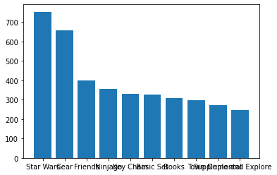

```python
plt.bar(merged_df_sorted.theme_name.iloc[:10], merged_df_sorted.nb_of_sets.iloc[:10])
```

That worked, but it's almost unreadable. 😩 The good thing for us is that we already know how to customize our charts! Here's what we get when we increase the size of our figure, add some labels, and most importantly, rotate the category names on the x-axis so that they don't overlap.

```
<BarContainer object of 10 artists>
```

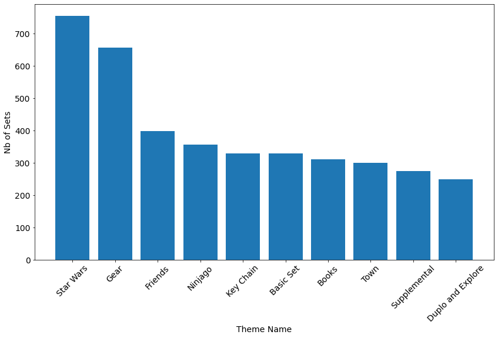

```python
plt.figure(figsize=(14,8))
plt.xticks(fontsize=14, rotation=45)
plt.yticks(fontsize=14)
plt.ylabel('Nb of Sets', fontsize=14)
plt.xlabel('Theme Name', fontsize=14)

plt.bar(merged_df_sorted.theme_name.iloc[:10], merged_df_sorted.nb_of_sets.iloc[:10])
```

### Learning Points & Summary

  ```
  https://drive.google.com/file/d/<ID of image>/view?usp=sharing
  ```

  We keep only the ID and we put it in this link to display our image:

  ```
  https://drive.google.com/uc?id=<ID of image>
  ```

  Solution found in [this link](https://medium.com/analytics-vidhya/embedding-your-image-in-google-colab-markdown-3998d5ac2684)